# Duke Sports Analtyics: Volleyball Project (Fall 2021)

Hillary Lee, Angel Chaudhary, Aditya Sardesai, Ethan Ouellette

# Introduction

This is an explanation of the data provided on the Duke website based on the FIVB VIS (Volleyball Information System):

[output not shown]

| SET | Description |
| --- | --- |
| Assists | Number of set assists. |
| Assists Per Set | Number of set assists per set. |
| Ball Handling Errors | Number of mistakes in setting. The opponent scores directly. |

| SERVE | Description |
| --- | --- |
| Aces | Number of points directly scored by the service. |
| Errors | Number of service mistakes. |
| Aces Per Set | Average number of serve aces per set. |

| RECEPTIONS | Description |
| --- | --- |
| Errors | Number of reception errors. |
| Errors Per Set | Average number of reception errors per set. |

| DEFENSE | Description |
| --- | --- |
| Digs | Number of outstanding digs. |
| Digs Per Set | Average number of digs per set. |

# Scraping Data

```r
library(tidyverse)
```

## Duke Data

The data is scraped from Duke Sport’s website: https://goduke.com/sports/vb/stats/2021?path=vb.

```r
url <- "https://goduke.com/sports/vb/stats/2021?path=vb"
Team_data_2021 <- xml2::read_html(url) %>%
  rvest::html_table(fill = T) %>%
  purrr::pluck(1) %>%
  janitor::clean_names() %>%
  dplyr::as_tibble() %>%
  select(-opponents_opp) %>%
  rename("2021" = duke)

url <- "https://goduke.com/sports/womens-volleyball/stats/2020"
Team_data_2020 <- xml2::read_html(url) %>%
  rvest::html_table(fill = T) %>%
  purrr::pluck(1) %>%
  janitor::clean_names() %>%
  dplyr::as_tibble() %>%
  select(-opponents_opp) %>%
  rename("2020" = duke)

url <- "https://goduke.com/sports/womens-volleyball/stats/2019"
Team_data_2019 <- xml2::read_html(url) %>%
  rvest::html_table(fill = T) %>%
  purrr::pluck(1) %>%
  janitor::clean_names() %>%
  dplyr::as_tibble() %>%
  select(-opponents_opp) %>%
  rename("2019" = duke)

Team_data_compiled <- left_join(left_join(Team_data_2021, Team_data_2020), Team_data_2019)

Team_data_compiled
```

```
# A tibble: 26 × 4
   statistic                                                `2021` `2020` `2019`
   <chr>                                                    <chr>  <chr>  <chr>
 1 "Attack"                                                 Attack Attack Attack
 2 "Kills\r\n                            K"                 1236   1053   1375
 3 "Errors\r\n                            ATE"              496    437    623
 4 "Attempts\r\n                            ATT"            3445   3006   4013
 5 "Percent\r\n                            ATT%"            .215   .205   .187
 6 "Kills Per Set\r\n                            K/S"       12.1   12.2   12.2
 7 "Set"                                                    Set    Set    Set
 8 "Assists\r\n                            AST"             1101   965    1253
 9 "Assists Per Set\r\n                            AST/S"   10.8   11.2   11.1
10 "Ball Handling Errors\r\n                            BH… 31     33     61
# … with 16 more rows
```

## NCAA Data

The data is scraped from the NCAA website: https://www.ncaa.com/stats/volleyball-women/d1/

```r
url <- "https://www.ncaa.com/stats/volleyball-women/d1/current/team/48"
NCAA_aces_per_set <- xml2::read_html(url) %>%
  rvest::html_table(fill = T) %>%
  purrr::pluck(1) %>%
  janitor::clean_names() %>%
  dplyr::as_tibble() %>%
  rename(
    "aces per set" = per_set,
    "sets" = s
  )

url <- "https://www.ncaa.com/stats/volleyball-women/d1/current/team/49"
NCAA_blocks_per_set <- xml2::read_html(url) %>%
  rvest::html_table(fill = T) %>%
  purrr::pluck(1) %>%
  janitor::clean_names() %>%
  dplyr::as_tibble() %>%
  rename(
    "blocks per set" = per_set,
    "sets" = s
  )

url <- "https://www.ncaa.com/stats/volleyball-women/d1/current/team/50"
NCAA_digs_per_set <- xml2::read_html(url) %>%
  rvest::html_table(fill = T) %>%
  purrr::pluck(1) %>%
  janitor::clean_names() %>%
  dplyr::as_tibble() %>%
  rename(
    "digs per set" = per_set,
    "sets" = s
  )

url <- "https://www.ncaa.com/stats/volleyball-women/d1/current/team/47"
NCAA_assists_per_set <- xml2::read_html(url) %>%
  rvest::html_table(fill = T) %>%
  purrr::pluck(1) %>%
  janitor::clean_names() %>%
  dplyr::as_tibble() %>%
  rename(
    "assists per set" = per_set,
    "sets" = s
  )

url <- "https://www.ncaa.com/stats/volleyball-women/d1/current/team/46"
NCAA_kills_per_set <- xml2::read_html(url) %>%
  rvest::html_table(fill = T) %>%
  purrr::pluck(1) %>%
  janitor::clean_names() %>%
  dplyr::as_tibble() %>%
  rename(
    "kills per set" = per_set,
    "sets" = s
  )

url <- "https://www.ncaa.com/stats/volleyball-women/d1/current/team/45"
NCAA_hitting_percentage <- xml2::read_html(url) %>%
  rvest::html_table(fill = T) %>%
  purrr::pluck(1) %>%
  janitor::clean_names() %>%
  dplyr::as_tibble() %>%
  rename("sets" = s)

NCAA_kills_per_set
```

```
# A tibble: 50 × 5
   rank  team              sets kills `kills per set`
   <chr> <chr>            <int> <int>           <dbl>
 1 1     Georgia Tech       112  1700            15.2
 2 2     Ohio St.           114  1667            14.6
 3 3     Wisconsin          122  1781            14.6
 4 4     UC Santa Barbara   120  1733            14.4
 5 5     Rice                93  1337            14.4
 6 6     Kentucky           106  1518            14.3
 7 7     Milwaukee          115  1639            14.2
 8 8     Utah               113  1610            14.2
 9 9     Pittsburgh         126  1792            14.2
10 10    Penn St.           119  1685            14.2
# … with 40 more rows
```

```r
NCAA_hitting_percentage
```

```
# A tibble: 50 × 7
    rank team          sets kills errors total_attacks   pct
   <int> <chr>        <int> <int>  <int>         <int> <dbl>
 1     1 Texas           99  1356    313          3044 0.343
 2     2 Western Ky.     97  1369    349          2988 0.341
 3     3 BYU            107  1502    399          3345 0.33
 4     4 Kentucky       106  1518    456          3530 0.301
 5     5 Louisville     113  1541    487          3548 0.297
 6     6 Georgia Tech   112  1700    576          3861 0.291
 7     7 Wisconsin      122  1781    547          4244 0.291
 8     8 Florida        106  1492    465          3545 0.29
 9     9 Rice            93  1337    393          3288 0.287
10    10 Washington     119  1638    529          3887 0.285
# … with 40 more rows
```

```r
NCAA_aces_per_set
```

```
# A tibble: 50 × 5
   rank  team           sets  aces `aces per set`
   <chr> <chr>         <int> <int>          <dbl>
 1 1     Howard          112   262           2.34
 2 2     Texas            99   218           2.2
 3 3     Delaware St.    105   227           2.16
 4 4     Delaware        102   220           2.16
 5 5     Weber St.       120   251           2.09
 6 6     Lipscomb        101   203           2.01
 7 7     Jackson St.     110   219           1.99
 8 8     USC Upstate     104   206           1.98
 9 9     Denver          104   202           1.94
10 10    Robert Morris   114   220           1.93
# … with 40 more rows
```

```r
NCAA_blocks_per_set
```

```
# A tibble: 50 × 6
   rank  team        sets block_solos block_assists `blocks per set`
   <chr> <chr>      <int>       <int>         <int>            <dbl>
 1 1     Maryland     112          47           603             3.11
 2 2     Tennessee    109          64           529             3.01
 3 3     Louisville   113         101           474             2.99
 4 4     Purdue       126          57           631             2.96
 5 5     Creighton    116          58           546             2.85
 6 6     Penn St.     119          89           495             2.83
 7 7     Boise St.    129          56           605             2.78
 8 8     UCF          125          55           582             2.77
 9 9     San Diego    103          65           431             2.72
10 10    Drake        100          51           440             2.71
# … with 40 more rows
```

```r
NCAA_digs_per_set
```

```
# A tibble: 50 × 5
    rank team               sets  digs `digs per set`
   <int> <chr>             <int> <int>          <dbl>
 1     1 Wright St.          120  2355           19.6
 2     2 Cal St. Fullerton   101  1966           19.5
 3     3 Niagara             107  2015           18.8
 4     4 Winthrop             97  1819           18.8
 5     5 Central Mich.       112  2100           18.8
 6     6 Loyola Maryland     102  1878           18.4
 7     7 Arkansas St.        114  2067           18.1
 8     8 Creighton           116  2069           17.8
 9     9 UNC Greensboro      116  2060           17.8
10    10 Tulsa               117  2075           17.7
# … with 40 more rows
```

```r
NCAA_assists_per_set
```

```
# A tibble: 50 × 5
    rank team              sets assists `assists per set`
   <int> <chr>            <int>   <int>             <dbl>
 1     1 Georgia Tech       112    1557              13.9
 2     2 Ohio St.           114    1549              13.6
 3     3 UC Santa Barbara   120    1620              13.5
 4     4 Wisconsin          122    1643              13.5
 5     5 Milwaukee          115    1542              13.4
 6     6 Pittsburgh         126    1671              13.3
 7     7 Florida            106    1401              13.2
 8     8 Rice                93    1227              13.2
 9     9 Murray St.         113    1483              13.1
10    10 Stanford           113    1481              13.1
# … with 40 more rows
```

The following is a brief explanation of how the statistics were collected by [NCAA regulations](http://fs.ncaa.org/Docs/stats/VB_Forms/Volleyball%20Box%20Score%20Form%20Instructions.pdf).

*Offense* * Attack + A kill is awarded any time an attack attempt is unreturnable by the opposition or any time the attack attempt leads directly to a blocking error by the opponent. + Kills per set = total kills / sets + Hitting percentage = (kills - errors) / Total attacks * Service Aces + A service ace is a serve that directly results in a point. + Aces per set = total team aces / sets

*Defense* * Blocks + Total team blocks are derived by adding all block solos to one half of the block assists. + Blocks per set = total team blocks / sets * Digs + A dig is awarded when a player successfully passes a ball that has been attacked by the opposition. + Digs are given only when players receive an attacked ball and it is kept in play. + Digs per set = total team digs / sets * Sets + An assist is awarded when a player passes, sets or digs a ball to a teammate who attacks the ball for a kill. + Assists per set = assists / sets

```r
library(readxl)
nitty_gritties <- read_excel("data/nitty_gritties.xlsx")
nitty_gritties
```

```
# A tibble: 15 × 19
   Team       Conference `Adj. RPI` `Adj. RPI Value` `Prev Adj. RPI`   RPI WL
   <chr>      <chr>           <dbl>            <dbl>           <dbl> <dbl> <chr>
 1 Louisville ACC                 1            0.757               1     1 32-1
 2 Pittsburgh ACC                 3            0.729               2     3 30-4
 3 Georgia T… ACC                 5            0.702               7     5 26-6
 4 Miami (FL) ACC                14            0.658              11    12 25-5
 5 Florida S… ACC                20            0.638              19    20 20-10
 6 North Car… ACC                32            0.610              28    31 21-9
 7 Notre Dame ACC                34            0.604              32    36 13-15
 8 Syracuse   ACC                42            0.587              41    42 17-13
 9 Duke       ACC                62            0.571              59    61 16-13
10 NC State   ACC                87            0.554              83    87 16-13
11 Boston Co… ACC               105            0.540             108   103 17-17
12 Wake Fore… ACC               107            0.537             105   109 15-14
13 Clemson    ACC               123            0.523             120   122 12-18
14 Virginia … ACC               139            0.515             135   138 12-18
15 Virginia   ACC               197            0.485             196   198 8-20
# … with 12 more variables: Adj. Non-Conf RPI <dbl>, Non-Conf Record <chr>,
#   Conf RPI <dbl>, Conf. Record <chr>, Road WL <chr>, Last 10 Games <chr>,
#   RPI 1-25 <chr>, RPI 26-50 <chr>, RPI 51-100 <chr>, RPI 101+ <chr>,
#   vs TOP 100 <chr>, vs below 150 <chr>
```

```r
nitty_gritties_full <- read_excel("data/NCAA_Statistics.xlsx")
nitty_gritties_full
```

```
# A tibble: 340 × 19
   Team       Conference `Adj. RPI` `Adj. RPI Value` `Prev Adj. RPI`   RPI WL
   <chr>      <chr>           <dbl>            <dbl>           <dbl> <dbl> <chr>
 1 Louisville ACC                 1            0.757               1     1 32-1
 2 Wisconsin  Big Ten             2            0.747               4     2 31-3
 3 Pittsburgh ACC                 3            0.729               2     3 30-4
 4 Texas      Big 12              4            0.717               3     4 27-2
 5 Georgia T… ACC                 5            0.702               7     5 26-6
 6 Nebraska   Big Ten             6            0.695              12     8 26-8
 7 Baylor     Big 12              7            0.695               5     6 22-6
 8 Kentucky   SEC                 8            0.687               6     7 25-5
 9 Purdue     Big Ten             9            0.687              10     9 26-7
10 Ohio St.   Big Ten            10            0.670               9    11 27-6
# … with 330 more rows, and 12 more variables: Adj. Non-Conf RPI <dbl>,
#   Non-Conf Record <chr>, Conf RPI <dbl>, Conf. Record <chr>, Road WL <chr>,
#   Last 10 Games <chr>, RPI 1-25 <chr>, RPI 26-50 <chr>, RPI 51-100 <chr>,
#   RPI 101+ <chr>, vs TOP 100 <chr>, vs below 150 <chr>
```

# Data Visualization

## Offense and Defense stats

Section authored by Hillary Lee.

### Offense

Service aces, kills, and hitting percentage are offensive stats that are compiled in this data.

```r
df1 <- NCAA_kills_per_set %>% select(-c(rank, sets))
df2 <- NCAA_aces_per_set %>% select(-c(rank, sets))
df3 <- NCAA_hitting_percentage %>% select(-c(rank, kills))

compiled_offense <- df1 %>%
  inner_join(df2, by = "team") %>%
  inner_join(df3, by = "team")
col_order <- c("team", "sets", "total_attacks", "kills", "errors", "aces", "kills per set", "pct", "aces per set")
compiled_offense <- compiled_offense[, col_order]
compiled_offense
```

```
# A tibble: 11 × 9
   team         sets total_attacks kills errors  aces `kills per set`   pct
   <chr>       <int>         <int> <int>  <int> <int>           <dbl> <dbl>
 1 Western Ky.    97          2988  1369    349   169            14.1 0.341
 2 BYU           107          3345  1502    399   191            14.0 0.33
 3 Marquette     113          4078  1584    523   189            14.0 0.26
 4 Washington    119          3887  1638    529   209            13.8 0.285
 5 Denver        104          3453  1431    524   202            13.8 0.263
 6 UTEP          127          4240  1744    593   222            13.7 0.271
 7 Texas          99          3044  1356    313   218            13.7 0.343
 8 Florida A&M   113          3854  1542    562   218            13.6 0.254
 9 Louisville    113          3548  1541    487   190            13.6 0.297
10 Evansville    118          4168  1607    570   214            13.6 0.249
11 UCF           125          4219  1699    527   217            13.6 0.278
# … with 1 more variable: aces per set <dbl>
```

### Defense

Blocks, digs, and assists are defensive stats that are compiled in this data.

```r
df1 <- NCAA_blocks_per_set %>% select(-c(rank, sets))
df2 <- NCAA_digs_per_set %>% select(-c(rank, sets))
df3 <- NCAA_assists_per_set %>% select(-c(rank))

compiled_defense <- df1 %>%
  inner_join(df2, by = "team") %>%
  inner_join(df3, by = "team")
col_order <- c("team", "sets", "block_solos", "block_assists", "digs", "assists", "blocks per set", "digs per set", "assists per set")
compiled_defense <- compiled_defense[, col_order]
compiled_defense
```

```
# A tibble: 3 × 9
  team       sets block_solos block_assists  digs assists `blocks per set`
  <chr>     <int>       <int>         <int> <int>   <int>            <dbl>
1 Creighton   116          58           546  2069    1482             2.85
2 Nebraska    121          38           530  2054    1548             2.5
3 Minnesota   117          45           489  1982    1463             2.47
# … with 2 more variables: digs per set <dbl>, assists per set <dbl>
```

```r
ncaa_and_nitty <- left_join(nitty_gritties_full, NCAA_assists_per_set,
  by = c("Team" = "team")
) %>%
  left_join(NCAA_aces_per_set, by = c("Team" = "team")) %>%
  left_join(NCAA_blocks_per_set, by = c("Team" = "team")) %>%
  left_join(NCAA_digs_per_set, by = c("Team" = "team")) %>%
  left_join(NCAA_hitting_percentage, by = c("Team" = "team")) %>%
  left_join(NCAA_kills_per_set, by = c("Team" = "team"))

ncaa_and_nitty
```

```
# A tibble: 340 × 46
   Team       Conference `Adj. RPI` `Adj. RPI Value` `Prev Adj. RPI`   RPI WL
   <chr>      <chr>           <dbl>            <dbl>           <dbl> <dbl> <chr>
 1 Louisville ACC                 1            0.757               1     1 32-1
 2 Wisconsin  Big Ten             2            0.747               4     2 31-3
 3 Pittsburgh ACC                 3            0.729               2     3 30-4
 4 Texas      Big 12              4            0.717               3     4 27-2
 5 Georgia T… ACC                 5            0.702               7     5 26-6
 6 Nebraska   Big Ten             6            0.695              12     8 26-8
 7 Baylor     Big 12              7            0.695               5     6 22-6
 8 Kentucky   SEC                 8            0.687               6     7 25-5
 9 Purdue     Big Ten             9            0.687              10     9 26-7
10 Ohio St.   Big Ten            10            0.670               9    11 27-6
# … with 330 more rows, and 39 more variables: Adj. Non-Conf RPI <dbl>,
#   Non-Conf Record <chr>, Conf RPI <dbl>, Conf. Record <chr>, Road WL <chr>,
#   Last 10 Games <chr>, RPI 1-25 <chr>, RPI 26-50 <chr>, RPI 51-100 <chr>,
#   RPI 101+ <chr>, vs TOP 100 <chr>, vs below 150 <chr>, rank.x <int>,
#   sets.x <int>, assists <int>, assists per set <dbl>, rank.y <chr>,
#   sets.y <int>, aces <int>, aces per set <dbl>, rank.x.x <chr>,
#   sets.x.x <int>, block_solos <int>, block_assists <int>, …
```

Section authored by Ethan Ouellette.

```r
lookup <- nitty_gritties_full[, c("Team", "Adj. RPI Value")]
hitting_pct <- NCAA_hitting_percentage[, c("team", "pct")]
hitting_pct_rpi <- merge(lookup, hitting_pct, by.x = "Team", by.y = "team")
names(hitting_pct_rpi)[2] <- "rpi"

hitting_pct_rpi
```

```
               Team     rpi   pct
1          Ball St. 0.61866 0.265
2            Baylor 0.69461 0.281
3         Boise St. 0.55940 0.256
4     Bowling Green 0.56952 0.248
5             Brown 0.56351 0.250
6               BYU 0.65769 0.330
7  Coastal Carolina 0.53878 0.252
8         Creighton 0.66764 0.245
9            Denver 0.55423 0.263
10             Elon 0.53248 0.248
11       Evansville 0.53398 0.249
12        Fairfield 0.52817 0.252
13             FGCU 0.60879 0.265
14          Florida 0.64518 0.290
```

[output cut: 36 more lines]

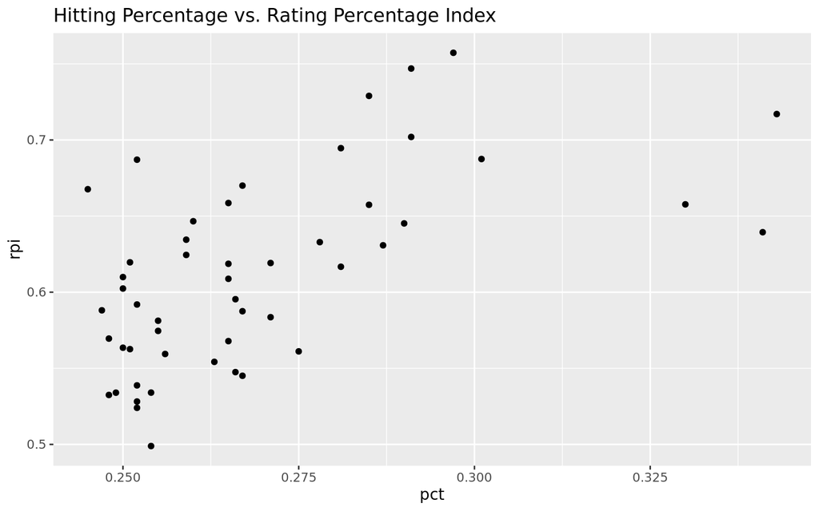

```r
ggplot(data = hitting_pct_rpi, mapping = aes(x = pct, y = rpi)) +
  geom_point() +
  labs(title = paste("Hitting Percentage vs. Rating Percentage Index"))
```

# Analysis

# Summary